# MAE augmentation : qPCR bias correction for 16S rRNA sequencing samples

Author

Mariam Rahali Masbouri, Khadija Rahali Masbouri, Laura Symul

Published

September 1, 2026

```r
library(tidyverse)
library(magrittr)
library(gt)
library(patchwork)
library(SummarizedExperiment)
library(tidySummarizedExperiment)
library(MultiAssayExperiment)
library(lme4)

tmp <- fs::dir_map("R scripts/", source)
tmp <- fs::dir_map("../VIBRANT-99-utils/R/", source)
rm(tmp)
theme_set(theme_light())
```

```r
mae_file <-
  fs::dir_ls(
    get_02_output_dir(),
    regexp = "mae_full_.*\\.rds$"
  ) |>
  sort(decreasing = TRUE) |>
  magrittr::extract(1)

cat(str_c(
  "Loading MultiAssayExperiment from: ",
  dirname(mae_file) |> basename(),
  "/",
  mae_file |> basename(),
  "\n"
))
```

```
Loading MultiAssayExperiment from: 02 MAEs/mae_full_20260702.rds
```

```r
mae <- readRDS(mae_file)

rm(mae_file)
```

## Introduction

qPCR measurements have been done in two runs: one for the weekly swabs and one for the daily swabs.

The data from these two runs have been processed and QCed separately: in the `03_qPCR.qmd` for the weekly swabs and in `30_qPCR_daily.qmd` for daily samples. For the weekly samples, the estimated `copies_per_swabs` were re-estimated from the raw data using two calibrations methods (LL3 and LM) because some standards appeared to not have run properly and the machine-estimated calibrations lines induced biases in the measurements. For details, see `03_qPCR.qmd`.

Although the “weekly” and “daily” swabs were collected at different times and locations (the weekly swabs were self-collected at the clinic while the daily swabs were self-collected at home) and stored, shipped, processed and analysed in different batches, some swabs have been collected on the same day by the same participants. Because we expect that the biological variability between swabs collected on the same day to be small, these swabs (matched by participant and study day) may be used to estimate potential biases between the two collection, storage, and processing batches.

The purpose of this analysis is to investigate whether such technical biases exist and estimate it, and if present, correct for it. We will do this using a mixed effects model that accounts for technical and sampling noise.

## Comparison of the total 16S in weekly *vs* daily samples

We first compare the qPCR measurements of total 16S rRNA gene copies per swab between weekly and daily samples, for the same participant and study day. We also compare the bias between sites (CAP and MGH) and between the different calibrations for the weekly qPCR assay (original, LL3, LM).

To do that, we create `qpcr_16S` `data.frame`, which combine both weekly and daily qPCR data for 16S rRNA gene sequencing samples, and to which we join the participant information (`pid`, `study_day`, `arm`, `site`).

```r
qpcr_16S <-
  bind_rows(
    mae[["qPCR_daily"]] |>
      as_tibble() |>
      dplyr::filter(.feature == "16S", !is.na(copies_per_swab_med)) |>
      select(uid, dilution, copies_per_swab_med) |>
      mutate(assay = "daily qPCR") |>
      expand_grid(calibration = c("orig", "LL3", "LM")),
    mae[["qPCR"]] |>
      as_tibble() |>
      dplyr::filter(.feature == "16S") |>
      select(
        uid,
        dilution,
        copies_per_swab_med,
        copies_per_swab_orig_med,
        copies_per_swab_LM_med
      ) |>
      pivot_longer(
        cols = c(
          copies_per_swab_med,
          copies_per_swab_orig_med,
          copies_per_swab_LM_med
        ),
        names_to = "calibration",
        names_pattern = "copies_per_swab_(.*)_med",
        values_to = "copies_per_swab_med"
      ) |>
      mutate(
        calibration = calibration |> str_replace_na("LL3"),
        assay = "weekly qPCR"
      )
  ) |>
  dplyr::left_join(
    mae@colData |>
      as_tibble() |>
      dplyr::select(
        uid,
        pid,
        visit_code,
        visit,
        study_day,
        sample_type,
        site,
        randomized,
        arm,
        ITT,
        mITT,
        PP
      ),
    by = join_by(uid)
  ) |>
  dplyr::filter(sample_type == "Clinical sample") |>
  mutate(calibration = calibration |> fct_inorder())
```

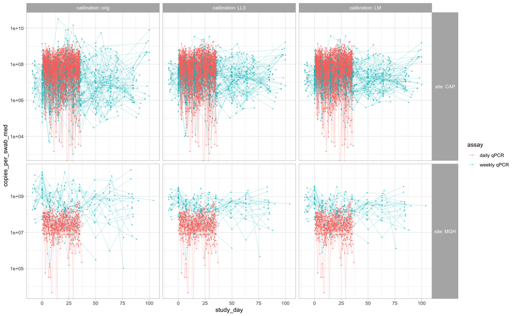

```r
qpcr_16S |>
  filter(randomized, study_day > -10) |>
  ggplot() +
  aes(x = study_day, y = copies_per_swab_med, color = assay) +
  facet_grid(
    site ~ calibration,
    scales = "free_y",
    space = "free_y",
    labeller = label_both
  ) +
  geom_line(aes(group = interaction(pid, assay)), alpha = 0.2) +
  geom_point(alpha = 0.5, size = 0.5) +
  scale_y_log10() +
  theme(
    strip.text.y = element_text(angle = 0)
  )
```

We filter the data to only keep samples where both weekly and daily qPCR measurements are available on the same study day for the same participant, and we visualize the relationship between the two assays for these samples.

```r
selected_time_points <-
  qpcr_16S |>
  filter(randomized) |>
  group_by(pid, study_day) |>
  mutate(n_assays = n_distinct(assay)) |>
  ungroup() |>
  dplyr::filter(n_assays == 2)

tmp <-
  dplyr::full_join(
    selected_time_points |>
      filter(assay == "weekly qPCR") |>
      dplyr::select(calibration, copies_per_swab_med, pid, study_day, site) |>
      dplyr::rename(copies_per_swab_med_weekly = copies_per_swab_med),
    selected_time_points |>
      filter(assay == "daily qPCR") |>
      dplyr::select(calibration, copies_per_swab_med, pid, study_day, site) |>
      distinct() |>
      dplyr::rename(copies_per_swab_med_daily = copies_per_swab_med)
  )
```

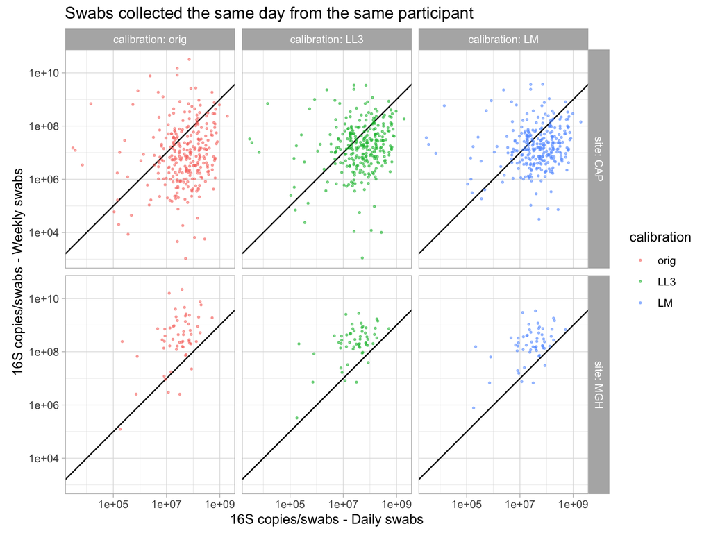

```r
tmp |>
  ggplot() +
  aes(
    x = copies_per_swab_med_daily,
    y = copies_per_swab_med_weekly,
    col = calibration
  ) +
  facet_grid(
    site ~ calibration,
    labeller = label_both
  ) +
  geom_abline(slope = 1, intercept = 0, color = "black") +
  geom_point(alpha = 0.5, size = 0.5) +
  scale_x_log10("16S copies/swabs - Daily swabs") +
  scale_y_log10("16S copies/swabs - Weekly swabs") +
  coord_fixed() +
  ggtitle("Swabs collected the same day from the same participant")
```

These visualizations suggest a bias between the weekly and daily qPCR measurements of the 16S rRNA copies per swabs: it looks like the concentrations are underestimated in the MGH daily samples compared to the MGH weekly samples, and underestimated in the CAP weekly samples compared to the CAP daily samples.

## Comparison of LBP strains in weekly *vs* daily samples

We also compare the qPCR measurements of LBP strains gene copies per swab between weekly and daily samples, for the same participant and study day.

```r
qpcr_LBP <-
  bind_rows(
    mae[["qPCR_daily"]] |>
      as_tibble() |>
      dplyr::filter(.feature != "16S", !is.na(copies_per_swab_med)) |>
      select(uid, dilution, target, copies_per_swab_med) |>
      mutate(assay = "daily qPCR"),
    mae[["qPCR"]] |>
      as_tibble() |>
      dplyr::filter(.feature != "16S") |>
      select(uid, dilution, target, copies_per_swab_med) |>
      mutate(assay = "weekly qPCR")
  ) |>
  dplyr::left_join(
    mae@colData |>
      as_tibble() |>
      dplyr::select(
        uid,
        pid,
        visit_code,
        visit,
        study_day,
        sample_type,
        site,
        randomized,
        arm,
        ITT,
        mITT,
        PP
      ),
    by = join_by(uid)
  ) |>
  dplyr::filter(sample_type == "Clinical sample")
```

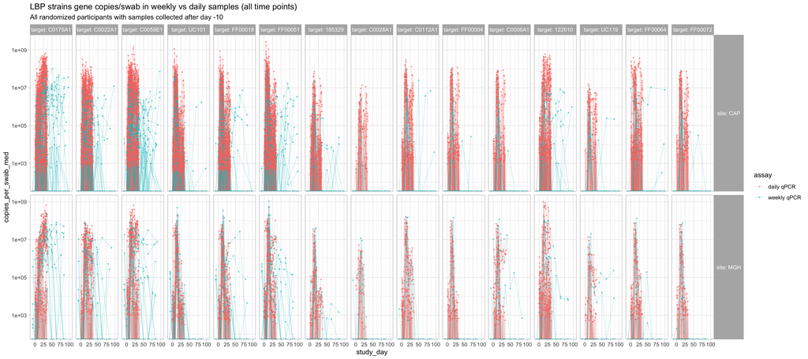

```r
qpcr_LBP |>
  filter(randomized, study_day > -10) |>
  ggplot() +
  aes(x = study_day, y = copies_per_swab_med, color = assay) +
  facet_grid(
    site ~ target,
    scales = "free_y",
    space = "free_y",
    labeller = label_both
  ) +
  geom_line(aes(group = interaction(pid, assay)), alpha = 0.2) +
  geom_point(alpha = 0.5, size = 0.5) +
  labs(
    title = "LBP strains gene copies/swab in weekly vs daily samples (all time points)",
    subtitle = "All randomized participants with samples collected after day -10"
  ) +
  scale_y_log10() +
  theme(
    strip.text.y = element_text(angle = 0)
  )
```

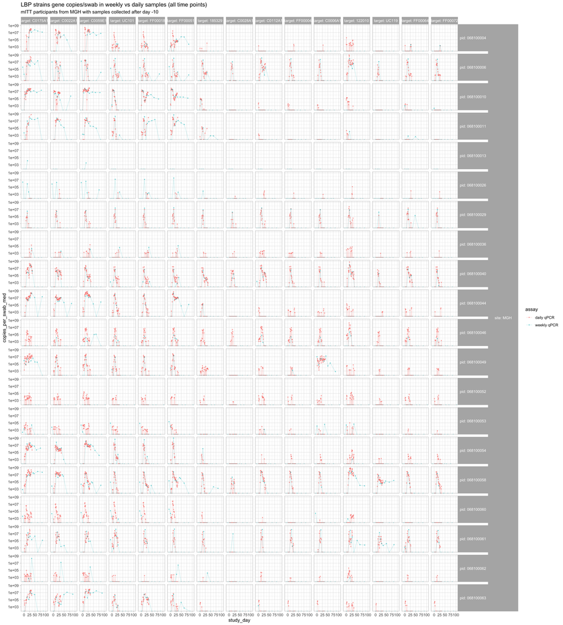

```r
qpcr_LBP |>
  filter(mITT, study_day > -10, site == "MGH") |>
  ggplot() +
  aes(x = study_day, y = copies_per_swab_med, color = assay) +
  ggh4x::facet_nested(site + pid ~ target, labeller = label_both) +
  geom_line(alpha = 0.2) +
  geom_point(alpha = 0.5, size = 0.5) +
  scale_y_log10() +
  labs(
    title = "LBP strains gene copies/swab in weekly vs daily samples (all time points)",
    subtitle = "mITT participants from MGH with samples collected after day -10"
  ) +
  theme(
    strip.text.y = element_text(angle = 0)
  )
```

```r
qpcr_LBP |>
  filter(mITT, study_day > -10, site == "CAP", arm == "LC-106-o") |>
  ggplot() +
  aes(x = study_day, y = copies_per_swab_med, color = assay) +
  ggplot2::facet_grid(pid ~ target) + #    , labeller = label_both
  geom_line(alpha = 0.2) +
  geom_point(alpha = 0.5, size = 0.5) +
  scale_y_log10() +
  theme(
    strip.text.y = element_text(angle = 0)
  )
```

[output not shown]

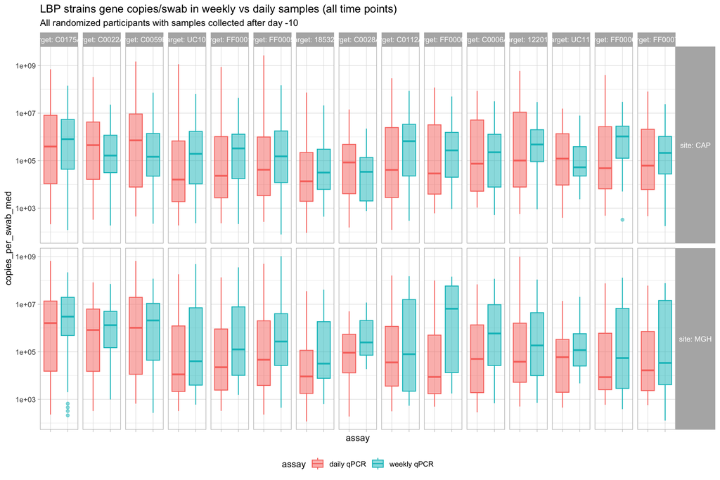

```r
qpcr_LBP |>
  filter(randomized, study_day > -10) |>
  ggplot() +
  aes(x = assay, y = copies_per_swab_med, color = assay, fill = assay) +
  facet_grid(
    site ~ target,
    scales = "free_y",
    space = "free_y",
    labeller = label_both
  ) +
  geom_boxplot(alpha = 0.5) +
  scale_y_log10() +
  labs(
    title = "LBP strains gene copies/swab in weekly vs daily samples (all time points)",
    subtitle = "All randomized participants with samples collected after day -10"
  ) +
  theme(
    strip.text.y = element_text(angle = 0),
    axis.text.x = element_blank(),
    legend.position = "bottom"
  )
```

We select the samples where both weekly and daily qPCR measurements are available on the same study day for the same participant, and we visualize the relationship between the two assays for these samples.

```r
selected_time_points <-
  qpcr_LBP |>
  filter(randomized) |>
  group_by(pid, study_day) |>
  mutate(n_assays = n_distinct(assay)) |>
  ungroup() |>
  dplyr::filter(n_assays == 2)

tmp <-
  dplyr::full_join(
    selected_time_points |>
      filter(assay == "weekly qPCR") |>
      dplyr::select(target, copies_per_swab_med, pid, study_day, site) |>
      dplyr::rename(copies_per_swab_med_weekly = copies_per_swab_med),
    selected_time_points |>
      filter(assay == "daily qPCR") |>
      dplyr::select(target, copies_per_swab_med, pid, study_day, site) |>
      distinct() |>
      dplyr::rename(copies_per_swab_med_daily = copies_per_swab_med)
  )
```

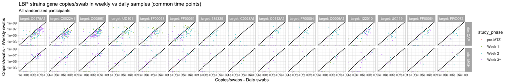

```r
tmp |>
  mutate(
    study_phase = case_when(
      study_day <= 0 ~ "pre-MTZ",
      study_day > 0 & study_day <= 7 ~ "Week 1",
      study_day <= 15 ~ "Week 2",
      TRUE ~ "Week 3+"
    ) |>
      factor(levels = c("pre-MTZ", "Week 1", "Week 2", "Week 3+"))
  ) |>
  ggplot() +
  aes(
    x = copies_per_swab_med_daily,
    y = copies_per_swab_med_weekly,
    col = study_phase
  ) +
  facet_grid(
    site ~ target,
    labeller = label_both
  ) +
  geom_abline(slope = 1, intercept = 0, color = "black") +
  geom_point(alpha = 0.5, size = 0.5) + # aes(col = study_day),
  scale_x_log10("Copies/swabs - Daily swabs") +
  scale_y_log10("Copies/swabs - Weekly swabs") +
  # scale_color_gradient(low = "dodgerblue1", high = "red") +
  labs(
    title = "LBP strains gene copies/swab in weekly vs daily samples (common time points)",
    subtitle = "All randomized participants"
  )
```

```r
coord_fixed()
```

[output not shown]

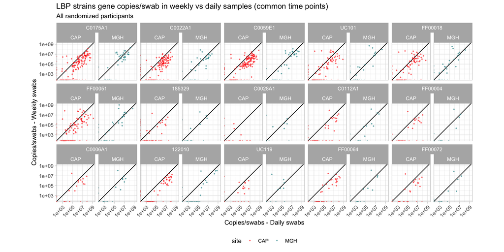

```r
tmp |>
  ggplot() +
  aes(
    x = copies_per_swab_med_daily,
    y = copies_per_swab_med_weekly,
    col = site
  ) +
  ggh4x::facet_nested_wrap(target + site ~ ., ncol = 10) +
  geom_abline(slope = 1, intercept = 0, color = "black") +
  geom_point(alpha = 0.5, size = 0.5) + # aes(col = study_day),
  scale_x_log10("Copies/swabs - Daily swabs") +
  scale_y_log10("Copies/swabs - Weekly swabs") +
  scale_color_manual(values = site_colors) +
  coord_fixed() +
  labs(
    title = "LBP strains gene copies/swab in weekly vs daily samples (common time points)",
    subtitle = "All randomized participants"
  ) +
  theme(
    legend.position = "bottom",
    axis.text.x = element_text(angle = 45, hjust = 1)
  )
```

It looks like a similar bias exist for the LBP strain concentrations suggesting that this was, as corroborated by Sinaye, due to a difference in DNA quality in these different groups of samples. However, for the LBP strain concentrations, the high proportion of zeros in the strain qPCR data makes applying the same bias-correction model used for 16S rRNA sequencing samples more challenging. Therefore, we will only estimate and correct for that technical bias in the 16S rRNA gene concentrations data.

## Estimation and corrections for the technical biases between the two batches (qPCR-estimated 16S concentrations)

The qPCR measurements appeared to be biased between the two batches, and that this bias depends on the study sites (CAP and MGH). The bias between batches is likely due to technical differences in the swabbing procedure and DNA extraction protocol, which were different for weekly and daily samples, as well as for CAP and MGH samples.

### qPCR bias correction for 16S rRNA concentrations (copies/swab)

We will first focus on the qPCR bias correction for 16S rRNA gene sequencing samples. For the weekly qPCR assay we select the LL3 calibration (`copies_per_swab_med`, which was the most adapted to the data - see `03_qpcr.qmd` for details).

```r
qpcr_16S <-
  qpcr_16S |>
  filter(calibration == "LL3") |>
  select(-calibration) |>
  # create "type" variable from "assay" variable only keeping "daily" (instead of "daily qPCR") and "weekly" (instead of "weekly qPCR")
  mutate(
    type = case_when(
      assay == "daily qPCR" ~ "daily",
      assay == "weekly qPCR" ~ "weekly",
      TRUE ~ "???"
    )
  ) |>
  select(-assay)
```

We create a new object `qpcr_same_day` from `qpcr_16S` that only keeps samples where both weekly and daily qPCR data are available on the same study day.

```r
qpcr_16S_same_day <-
  qpcr_16S |>
  group_by(pid, study_day) |>
  mutate(n_assays = type |> unique() |> length()) |>
  ungroup() |>
  filter(n_assays == 2)
```

We also create another variable `study_day_uid`, which is the concatenation of the participant identifier and study day.

```r
qpcr_16S_same_day <-
  qpcr_16S_same_day |>
  mutate(
    pid = pid |> factor(),
    swab_id = str_c(pid, "_", study_day, "_", type),
    study_day_uid = str_c(pid, "_", study_day) |> factor()
  )
```

We will now fit a linear mixed model using `lmer()` from the `lme4` library.

We consider the following factors:

fixed factors

- A: swab type (2 levels: weekly, daily) ($i$)
- B: study site (2 levels: CAP or MGH) ($j$)

and random factors

- C: participant, nested within B (study site), crossed with A (swab type) ($k(j)$)
- D: study day, nested within C (participant), crossed with A (swab type) ($l(k(j))$)

with

$Y_{ijklm} = \mu + \alpha_i + \beta_j + \gamma_{ij} + C_{k(j)} + D_{l(k(j))} + \epsilon_{ijklm}$

where $Y_{ijklm}$ is the measured 16S gene number of copies per swab, log-10 transformed.

We note that there were technical triplicates for the qPCR measurements (*i.e.*, 3 wells from the same swab per visit), which are not explicitly modeled here because the aggregation considered the median across triplicates for a more robust estimation of the concentrations. However, in a separate document, we also considered a model fitted on the non-aggregated data to compare the purely technical variance (variance across triplicates) and the sampling + analysis variance, and without much suprise, that model estimated very small purely technical variability.

**Note**

Based on the discussion from 10 December 2025 (VIBRANT analysis meeting), we concluded that DNA quality was lower in weekly swabs at CAP, motivating the use of MGH daily swabs as reference levels for correction.

Therefore, below, we relevel the `site` and `type` variables to set MGH and daily as the reference levels, respectively.

```r
qpcr_16S_same_day$site <- relevel(factor(qpcr_16S_same_day$site), ref = "MGH")
qpcr_16S_same_day$type <- relevel(factor(qpcr_16S_same_day$type), ref = "daily")

model_processed <-
  lme4::lmer(
    log10(copies_per_swab_med) ~ site * type + (1 | pid / study_day_uid),
    data = qpcr_16S_same_day
  )

summary(model_processed)
```

```
Linear mixed model fit by REML ['lmerMod']
Formula: log10(copies_per_swab_med) ~ site * type + (1 | pid/study_day_uid)
   Data: qpcr_16S_same_day

REML criterion at convergence: 1746.1

Scaled residuals:
    Min      1Q  Median      3Q     Max
-4.5622 -0.4217  0.0896  0.5872  2.7659

Random effects:
 Groups            Name        Variance Std.Dev.
 study_day_uid:pid (Intercept) 0.02381  0.1543
 pid               (Intercept) 0.11320  0.3364
 Residual                      0.63790  0.7987
Number of obs: 687, groups:  study_day_uid:pid, 343; pid, 90

Fixed effects:
                   Estimate Std. Error t value
(Intercept)          7.4101     0.1348  54.963
siteCAP              0.2088     0.1486   1.405
typeweekly           0.9151     0.1496   6.117
siteCAP:typeweekly  -1.3389     0.1638  -8.173

Correlation of Fixed Effects:
            (Intr) sitCAP typwkl
siteCAP     -0.907
typeweekly  -0.555  0.503
stCAP:typwk  0.507 -0.551 -0.913
```

```r
confint(model_processed)
```

```
                         2.5 %     97.5 %
.sig01              0.00000000  0.3248217
.sig02              0.23805947  0.4276090
.sigma              0.74033218  0.8550931
(Intercept)         7.14674632  7.6735053
siteCAP            -0.08161785  0.4992317
typeweekly          0.62188871  1.2082702
siteCAP:typeweekly -1.65994151 -1.0178646
```

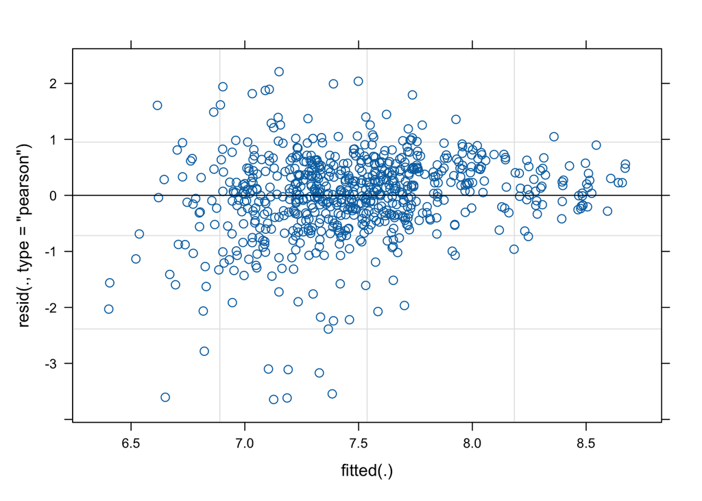

```r
plot(model_processed)
```

From the model summary, we can see that there is a significant difference between weekly and daily qPCR measurements, which differs by site (*c.f.*, interaction term).

We will correct for weekly (processed) qPCR values using the model estimates for the fixed effects.

```r
weekly_swab_effect <- lme4::fixef(model_processed)["typeweekly"]
weekly_site_interaction_effect <- lme4::fixef(model_processed)[
  "siteCAP:typeweekly"
]

qpcr_16S_processed <-
  qpcr_16S |>
  mutate(
    log_copies_per_swab = log10(copies_per_swab_med),
    copies_per_swab_corrected_log = log_copies_per_swab -
      ifelse(type == "weekly", weekly_swab_effect, 0) -
      ifelse(
        type == "weekly" & site == "CAP",
        weekly_site_interaction_effect,
        0
      ),
    copies_per_swab_corrected = 10^(copies_per_swab_corrected_log)
  )
```

The bias-corrected qPCR values are visualized in the plots below.

```r
qpcr_same_day_wide <-
  qpcr_16S_processed |>
  select(
    pid,
    study_day,
    type,
    copies_per_swab_med,
    copies_per_swab_corrected,
    site
  ) |>
  group_by(pid, study_day, type, site) |>
  summarise(
    copies_per_swab_med = mean(copies_per_swab_med),
    copies_per_swab_corrected = mean(copies_per_swab_corrected),
    .groups = "drop"
  ) |>
  pivot_wider(
    names_from = type,
    values_from = c(copies_per_swab_med, copies_per_swab_corrected),
    names_prefix = ""
  )
```

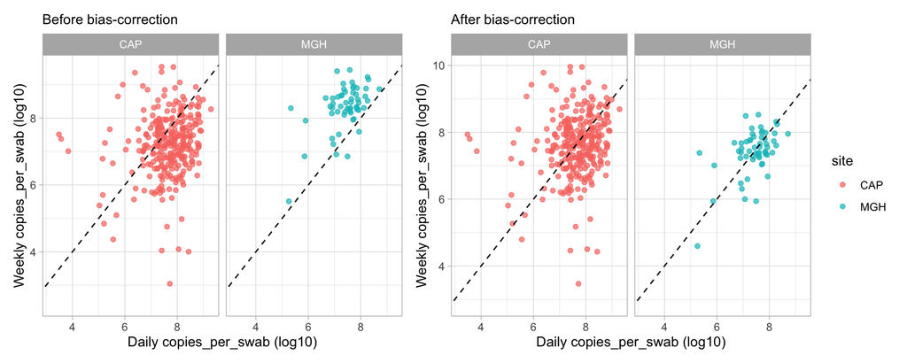

```r
p1 <- qpcr_same_day_wide |>
  ggplot() +
  aes(
    x = log10(copies_per_swab_med_daily),
    y = log10(copies_per_swab_med_weekly),
    color = site
  ) +
  geom_point(alpha = 0.7) +
  geom_abline(slope = 1, intercept = 0, linetype = "dashed", color = "black") +
  facet_wrap(~site) +
  labs(
    x = "Daily copies_per_swab (log10)",
    y = "Weekly copies_per_swab (log10)",
    subtitle = "Before bias-correction"
  )

p2 <- qpcr_same_day_wide |>
  ggplot() +
  aes(
    x = log10(copies_per_swab_corrected_daily),
    y = log10(copies_per_swab_corrected_weekly),
    color = site
  ) +
  geom_point(alpha = 0.7) +
  geom_abline(slope = 1, intercept = 0, linetype = "dashed", color = "black") +
  facet_wrap(~site) +
  labs(
    x = "Daily copies_per_swab (log10)",
    y = "Weekly copies_per_swab (log10)",
    subtitle = "After bias-correction"
  )

p1 + p2 + plot_layout(guides = "collect")
```

```r
line_params_16S <-
  qpcr_same_day_wide |>
  group_by(site) |>
  summarise(
    fit = list(lm(
      log10(copies_per_swab_med_weekly) ~ log10(copies_per_swab_med_daily)
    )),
    .groups = "drop"
  ) |>
  mutate(
    intercept = map_dbl(fit, ~ coef(.x)[1]),
    slope = map_dbl(fit, ~ coef(.x)[2])
  ) |>
  select(-fit)
```

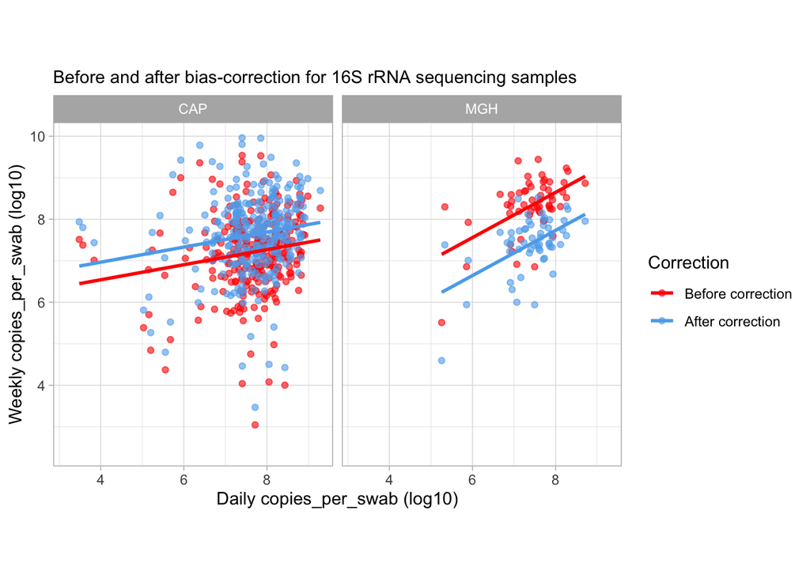

```r
qpcr_combined <-
  bind_rows(
    qpcr_same_day_wide |>
      mutate(
        daily = log10(copies_per_swab_med_daily),
        weekly = log10(copies_per_swab_med_weekly),
        type = "Before correction"
      ),
    qpcr_same_day_wide |>
      mutate(
        daily = log10(copies_per_swab_corrected_daily),
        weekly = log10(copies_per_swab_corrected_weekly),
        type = "After correction"
      )
  ) |>
  mutate(
    type = type |> factor(levels = c("Before correction", "After correction"))
  )

qpcr_combined |>
  ggplot() +
  aes(x = daily, y = weekly, color = type) +
  geom_point(alpha = 0.6) +
  geom_smooth(method = "lm", se = FALSE) +
  facet_wrap(~site) +
  scale_color_manual(values = c("red", "steelblue2")) +
  coord_fixed() +
  labs(
    x = "Daily copies_per_swab (log10)",
    y = "Weekly copies_per_swab (log10)",
    color = "Correction",
    subtitle = "Before and after bias-correction for 16S rRNA sequencing samples"
  )
```

### qPCR bias correction for LBP strains concentrations (copies/swab)

```r
qpcr_LBP <-
  qpcr_LBP |>
  # create "type" for the same reason as for qpcr_16S
  mutate(
    type = case_when(
      assay == "daily qPCR" ~ "daily",
      assay == "weekly qPCR" ~ "weekly",
      TRUE ~ "???"
    )
  ) |>
  select(-assay)
```

The relationship between sites (CAP or MGH) as well as sample type (weekly or daily) is visualized in the plots below.

```r
tmp <-
  qpcr_LBP |>
  select(pid, study_day, type, target, copies_per_swab_med, site) |>
  group_by(pid, study_day, type, site, target) |>
  summarise(
    copies_per_swab_med = mean(copies_per_swab_med),
    .groups = "drop"
  ) |>
  pivot_wider(
    names_from = type,
    values_from = copies_per_swab_med,
    names_prefix = ""
  )
```

```r
strain_centroid <-
  tmp |>
  group_by(site) |>
  summarise(
    x_mean = mean(log10(daily + 1), na.rm = TRUE),
    y_mean = mean(log10(weekly + 1), na.rm = TRUE)
  ) |>
  ungroup()

bias_line_on_strain <-
  strain_centroid |>
  mutate(
    slope = 1,
    intercept = (y_mean - x_mean) +
      case_when(
        site == "MGH" ~ weekly_swab_effect, # 0.9279943
        site == "CAP" ~ weekly_swab_effect + weekly_site_interaction_effect # 0.9279943 + (-1.352144)
      )
  )
```

```r
tmp |>
  ggplot() +
  aes(x = log10(daily + 1), y = log10(weekly + 1), color = site) +
  geom_point() +
  geom_abline(slope = 1, intercept = 0, linetype = "dashed", color = "black") +
  ggh4x::facet_nested_wrap(
    facets = ~site,
  ) +
  labs(
    x = "Daily copies_per_swab",
    y = "Weekly copies_per_swab",
    subtitle = "Before bias-correction",
    color = "Study site"
  )
```

[output not shown]

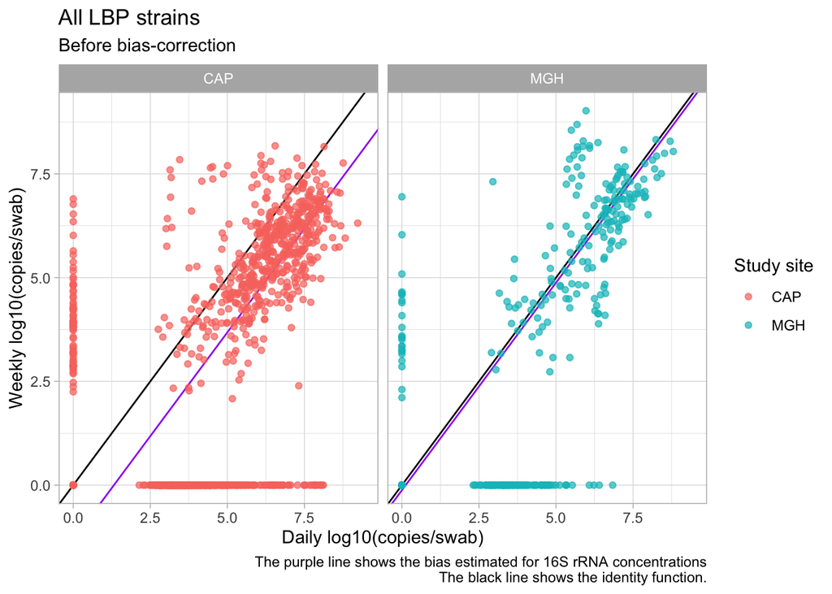

```r
tmp |>
  ggplot() +
  aes(x = log10(daily + 1), y = log10(weekly + 1), color = site) +
  geom_abline(slope = 1, intercept = 0, color = "black") +
  geom_abline(
    data = bias_line_on_strain,
    aes(slope = slope, intercept = intercept),
    color = "purple"
  ) +
  geom_point(alpha = 0.7) +
  ggh4x::facet_nested_wrap(
    facets = ~site,
  ) +
  labs(
    x = "Daily log10(copies/swab)",
    y = "Weekly log10(copies/swab)",
    title = "All LBP strains",
    subtitle = "Before bias-correction",
    color = "Study site",
    caption = "The purple line shows the bias estimated for 16S rRNA concentrations\nThe black line shows the identity function."
  )
```

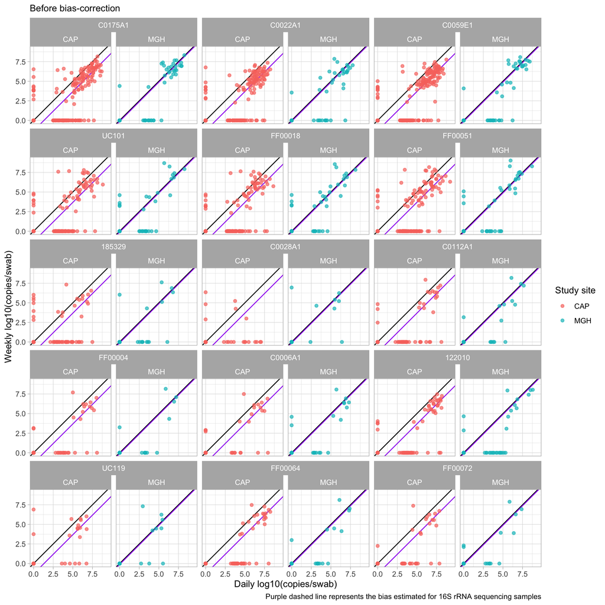

```r
tmp |>
  ggplot() +
  aes(x = log10(daily + 1), y = log10(weekly + 1), color = site) +
  geom_abline(slope = 1, intercept = 0, color = "black") +
  geom_abline(
    data = bias_line_on_strain,
    aes(slope = slope, intercept = intercept),
    color = "purple"
  ) +
  geom_point(alpha = 0.7) +
  ggh4x::facet_nested_wrap(
    facets = ~ target + site,
  ) +
  labs(
    x = "Daily log10(copies/swab)",
    y = "Weekly log10(copies/swab)",
    subtitle = "Before bias-correction",
    color = "Study site",
    caption = "Purple dashed line represents the bias estimated for 16S rRNA sequencing samples"
  )
```

From the plots above, we can indeed see that the bias between weekly and daily measurements for the LBP strains is similar to the bias observed for the total 16S rRNA concentrations, as the purple line (representing the bias estimated for the 16S rRNA concentrations) is close to the trend of the cloud of points for the strains concentrations.

**Warning**

The high proportion of zeros in the strain qPCR data makes applying the same bias-correction model used for 16S qPCR impractical. No correction is therefore planned for strain samples at this stage, and any analyses involving strain qPCR values should be interpreted with caution.

### Saving the results

Below, we save the bias-corrected qPCR data for 16S rRNA gene concentrations in the `MAE` object.

```r
qpcr_16S_processed <-
  qpcr_16S_processed |>
  mutate(.feature = "16S", .sample = uid) |>
  select(.feature, .sample, everything()) |>
  filter(type == "weekly")
```

```r
qpcr_df <- mae@ExperimentList$qPCR |> as_tibble()

qpcr_df <-
  qpcr_df |>
  left_join(
    qpcr_16S_processed |>
      select(.feature, .sample, uid, copies_per_swab_corrected) |>
      dplyr::rename(copies_per_swab_med_corrected = copies_per_swab_corrected),
    by = join_by(.feature, .sample, uid)
  ) |>
  relocate(copies_per_swab_med_corrected, .after = copies_per_swab_med)
```

```r
new_assay <-
  qpcr_df |>
  mutate(
    copies_per_swab_med_corrected = coalesce(
      copies_per_swab_med_corrected,
      copies_per_swab_med
    )
  ) |>
  select(.feature, .sample, copies_per_swab_med_corrected) |>
  pivot_wider(
    names_from = .sample,
    values_from = copies_per_swab_med_corrected
  ) |>
  column_to_rownames(".feature") |>
  as.matrix()

assay(mae@ExperimentList$qPCR, "copies_per_swab_med_corrected") <- new_assay
```

## Checking the participants time series after correction

```r
qpcr_16S <-
  bind_rows(
    mae[["qPCR_daily"]] |>
      as_tibble() |>
      dplyr::filter(.feature == "16S", !is.na(copies_per_swab_med)) |>
      select(uid, dilution, copies_per_swab_med) |>
      mutate(assay = "daily qPCR") |>
      expand_grid(correction = c("uncorrected", "corrected")),
    mae[["qPCR"]] |>
      as_tibble() |>
      dplyr::filter(.feature == "16S") |>
      select(
        uid,
        dilution,
        copies_per_swab_med,
        copies_per_swab_med_corrected
      ) |>
      pivot_longer(
        cols = c(copies_per_swab_med, copies_per_swab_med_corrected),
        names_to = "correction",
        names_pattern = "copies_per_swab_med_(.*)",
        values_to = "copies_per_swab_med"
      ) |>
      mutate(
        correction = correction |> str_replace_na("uncorrected"),
        assay = "weekly qPCR"
      )
  ) |>
  dplyr::left_join(
    mae@colData |>
      as_tibble() |>
      dplyr::select(
        uid,
        pid,
        visit_code,
        visit,
        study_day,
        sample_type,
        site,
        randomized,
        arm,
        ITT,
        mITT,
        PP
      ),
    by = join_by(uid)
  ) |>
  dplyr::filter(sample_type == "Clinical sample") |>
  mutate(correction = correction |> fct_inorder())
```

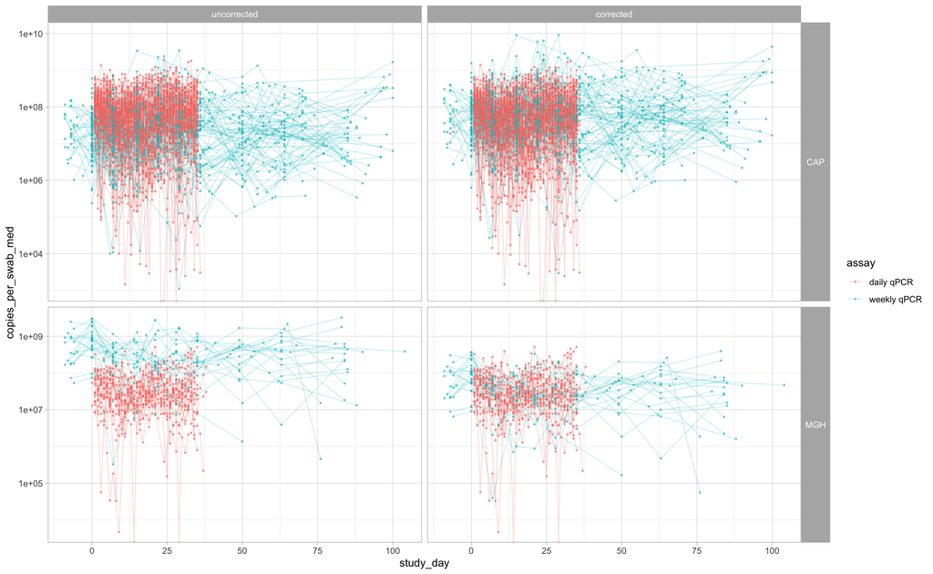

```r
qpcr_16S |>
  filter(randomized, study_day > -10) |>
  ggplot() +
  aes(x = study_day, y = copies_per_swab_med, color = assay) +
  facet_grid(
    site ~ correction,
    scales = "free_y",
    space = "free_y"
  ) +
  geom_line(aes(group = interaction(pid, assay)), alpha = 0.2) +
  geom_point(alpha = 0.5, size = 0.5) +
  scale_y_log10() +
  theme(
    strip.text.y = element_text(angle = 0)
  )
```

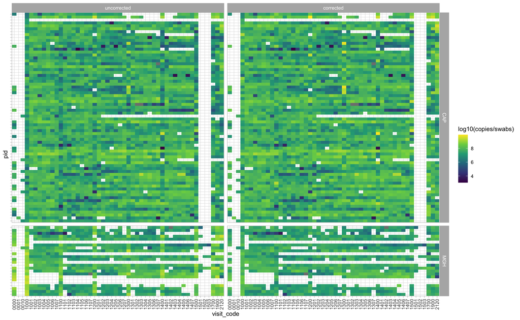

```r
p <-
  qpcr_16S |>
  filter(randomized, study_day > -10) |>
  ggplot() +
  aes(x = visit_code, y = pid, fill = copies_per_swab_med |> log10()) +
  facet_grid(
    site ~ correction,
    scales = "free_y",
    space = "free_y"
  ) +
  geom_tile() +
  scale_fill_viridis_c("log10(copies/swabs)") +
  theme(
    axis.text.y = element_blank(),
    axis.text.x = element_text(angle = 90, vjust = 0.5)
  )


p
```

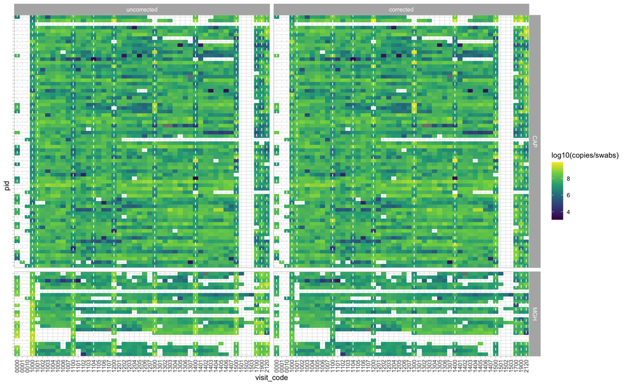

```r
p +
  geom_vline(
    data = qpcr_16S |>
      filter(assay == "weekly qPCR") |>
      select(visit_code) |>
      distinct(),
    aes(xintercept = visit_code),
    linetype = "dashed",
    color = "white"
  )
```

## Checking potential extraction plate effects after correction

```r
qpcr_16S_with_plates <-
  qpcr_16S |>
  filter(correction == "corrected") |>
  left_join(
    mae@metadata$sample_manifest |> filter(source_assay |> str_detect("qPCR")),
    by = join_by(uid)
  )
```

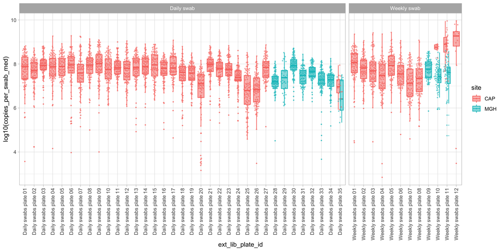

```r
qpcr_16S_with_plates |>
  group_by(ext_lib_plate_id) |>
  mutate(n_uid = n_distinct(uid)) |>
  ungroup() |>
  filter(n_uid > 10) |>
  mutate(pid = pid |> factor(), pid = pid |> factor(levels = sample(levels(pid)))) |>
  ggplot() +
  facet_grid(. ~ ext_lib_plate_batch, scales = "free", space = "free") +
  aes(x = ext_lib_plate_id, y = copies_per_swab_med |> log10(), color = site, fill = site) +
  geom_boxplot(alpha = 0.5, outlier.size = 0.2) +
  ggbeeswarm::geom_quasirandom(alpha = 0.5, size = 0.5) + # aes(col = pid),
  # guides(col = "none") +
  theme(axis.text.x = element_text(angle = 90, vjust = 0.5, hjust = 1))
```

There might be a few plates with much lower 16S concentrations than the others (e.g., daily plates 20, 25, 26…)

This may be due to technical issues (e.g., DNA extraction issues) or due to biological reasons (e.g., some participants may have lower 16S concentrations than others, or samples from similar visits grouped on a single plate). Unfortunately, there wasn’t sufficient randomization of samples across plates to disentangle well these effects.

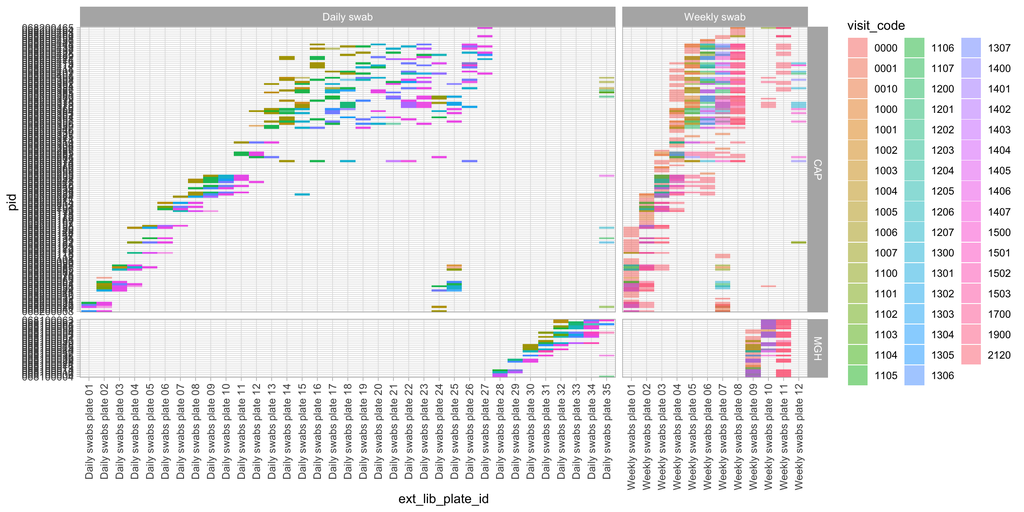

```r
qpcr_16S_with_plates |>
  group_by(ext_lib_plate_id) |>
  mutate(n_uid = n_distinct(uid)) |>
  ungroup() |>
  filter(n_uid > 10) |>
  ggplot() +
  facet_grid(site ~ ext_lib_plate_batch, scales = "free", space = "free") +
  aes(y = pid, x = ext_lib_plate_id, fill = visit_code) +
  geom_tile(alpha = 0.5) +
  theme(axis.text.x = element_text(angle = 90, vjust = 0.5, hjust = 1))
```

We fit a linear mixed model to estimate the plate effect while accounting for participant and visit effects. We only include plates with at least 8 unique participants.

```r
mmodel_plate_pid <-
  lmerTest::lmer(
    log10(copies_per_swab_med) ~ ext_lib_plate_id + (1 | pid) + (1 | visit_code),
    data = qpcr_16S_with_plates |>
      group_by(ext_lib_plate_id) |>
      mutate(n_uid = n_distinct(uid), n_pid = n_distinct(pid)) |>
      ungroup() |>
      filter(n_uid > 10, n_pid >= 8, !is.na(copies_per_swab_med), copies_per_swab_med > 0)
  )

mmodel_plate_pid |> summary()
```

```
Linear mixed model fit by REML. t-tests use Satterthwaite's method [
lmerModLmerTest]
Formula: log10(copies_per_swab_med) ~ ext_lib_plate_id + (1 | pid) + (1 |
    visit_code)
   Data:
filter(ungroup(mutate(group_by(qpcr_16S_with_plates, ext_lib_plate_id),
    n_uid = n_distinct(uid), n_pid = n_distinct(pid))), n_uid >
    10, n_pid >= 8, !is.na(copies_per_swab_med), copies_per_swab_med >      0)

REML criterion at convergence: 6721.1

Scaled residuals:
    Min      1Q  Median      3Q     Max
-7.4522 -0.4347  0.1086  0.5872  3.4503

Random effects:
 Groups     Name        Variance Std.Dev.
 pid        (Intercept) 0.144496 0.38013
 visit_code (Intercept) 0.008548 0.09245
 Residual               0.412953 0.64261
Number of obs: 3250, groups:  pid, 165; visit_code, 50

Fixed effects:
                                        Estimate Std. Error         df t value
(Intercept)                              7.44370    0.09936  896.46505  74.920
ext_lib_plate_idDaily swabs plate 03     0.33697    0.10780 3204.23297   3.126
ext_lib_plate_idDaily swabs plate 04     0.18682    0.12203 3010.66000   1.531
ext_lib_plate_idDaily swabs plate 06     0.24111    0.13603 2070.37063   1.772
ext_lib_plate_idDaily swabs plate 08     0.28162    0.13308 1854.33586   2.116
ext_lib_plate_idDaily swabs plate 09     0.39601    0.13304 1843.96203   2.977
ext_lib_plate_idDaily swabs plate 10     0.21196    0.13388 1906.06318   1.583
ext_lib_plate_idDaily swabs plate 11     0.47023    0.13468 1853.91486   3.492
ext_lib_plate_idDaily swabs plate 13     0.20472    0.12708 2446.13420   1.611
ext_lib_plate_idDaily swabs plate 14     0.27529    0.12225 2526.39102   2.252
ext_lib_plate_idDaily swabs plate 15     0.37760    0.12234 2641.05454   3.087
ext_lib_plate_idDaily swabs plate 16     0.21829    0.12474 2406.17703   1.750
ext_lib_plate_idDaily swabs plate 17     0.25610    0.12269 2575.68005   2.087
ext_lib_plate_idDaily swabs plate 18    -0.12564    0.12305 2560.57592  -1.021
ext_lib_plate_idDaily swabs plate 19     0.02112    0.12537 2396.37080   0.168
ext_lib_plate_idDaily swabs plate 20    -0.67750    0.12617 2398.26326  -5.370
```

[output cut: 50 more lines]

```
ext_lib_plate_idDaily swabs plate 35  0.004208 **
ext_lib_plate_idWeekly swabs plate 01 0.000142 ***
ext_lib_plate_idWeekly swabs plate 02 0.147404
ext_lib_plate_idWeekly swabs plate 03 0.151747
ext_lib_plate_idWeekly swabs plate 04 0.214926
ext_lib_plate_idWeekly swabs plate 05 0.001132 **
ext_lib_plate_idWeekly swabs plate 06 0.619455
ext_lib_plate_idWeekly swabs plate 07 0.000899 ***
ext_lib_plate_idWeekly swabs plate 08 0.006880 **
ext_lib_plate_idWeekly swabs plate 09 3.19e-05 ***
ext_lib_plate_idWeekly swabs plate 10 0.001116 **
ext_lib_plate_idWeekly swabs plate 11 0.000966 ***
ext_lib_plate_idWeekly swabs plate 12 7.45e-11 ***
---
Signif. codes:  0 '***' 0.001 '**' 0.01 '*' 0.05 '.' 0.1 ' ' 1
```

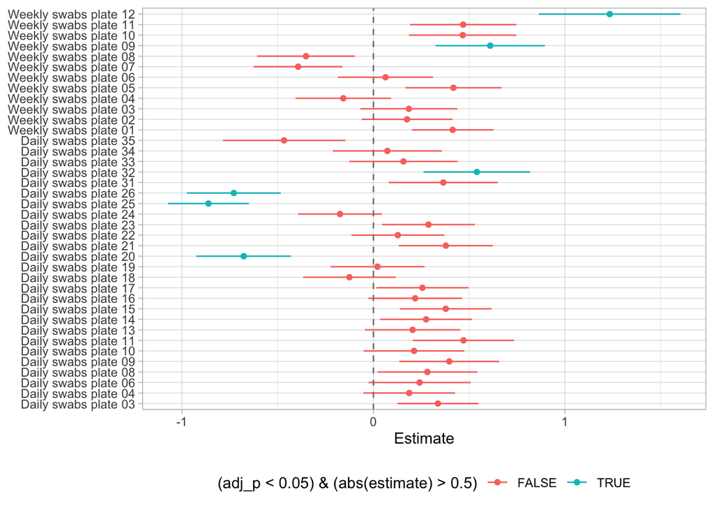

```r
# make a plot of the fixed effects of the plate effect model
library(broom.mixed)

tidy(mmodel_plate_pid, effects = "fixed", conf.int = TRUE) |>
  # optional: drop intercept
  dplyr::filter(term != "(Intercept)") |>
  mutate(
    term = term |> str_remove("ext_lib_plate_id") |> str_trim(),
    adj_p = p.adjust(p.value, method = "BH")
  ) |>
  ggplot(aes(
    x = estimate,
    xmin = conf.low,
    xmax = conf.high,
    y = term,
    col = (adj_p < 0.05) & (abs(estimate) > 0.5)
  )) +
  geom_pointrange(size = 0.2) +
  geom_vline(xintercept = 0, linetype = "dashed", colour = "grey50") +
  labs(x = "Estimate", y = NULL) +
  theme(legend.position = "bottom")
```

```r
show_timeline_of_participants_with_samples_on_plate_x <- function(qpcr_16S_with_plates, plate_nb) {
  qpcr_16S_with_plates |>
    group_by(ext_lib_plate_id) |>
    mutate(n_uid = n_distinct(uid)) |>
    ungroup() |>
    filter(n_uid > 10, !is.na(copies_per_swab_med), copies_per_swab_med > 0) |>
    group_by(pid) |>
    mutate(has_samples_on_plate_x = any(ext_lib_plate_nb %in% plate_nb)) |>
    mutate(color = ifelse(ext_lib_plate_nb %in% plate_nb, ext_lib_plate_nb, NA) |> factor()) |>
    ungroup() |>
    filter(has_samples_on_plate_x) |>
    ggplot() +
    facet_wrap(pid ~ ., scales = "free_y") +
    aes(x = study_day, y = copies_per_swab_med |> log10(), color = color) +
    geom_point(alpha = 0.5, size = 0.5) +
    geom_line(aes(group = pid)) +
    labs(
      title = str_c("Participants with samples on plates ", plate_nb |> str_c(collapse = ",")),
      x = "Study day",
      y = "log10(copies/swab)",
      color = "Plate"
    ) +
    theme(legend.position = "bottom")
}
```

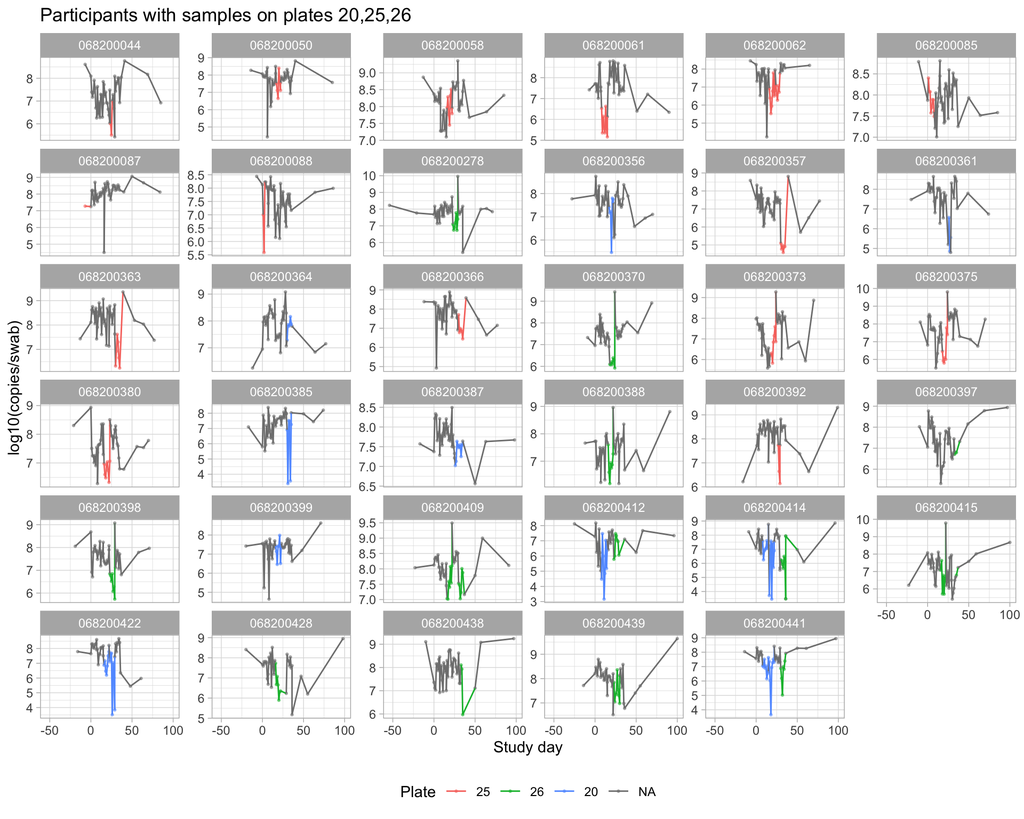

```r
# show_timeline_of_participants_with_samples_on_plate_x(qpcr_16S_with_plates, plate_nb = 20)
# show_timeline_of_participants_with_samples_on_plate_x(qpcr_16S_with_plates, plate_nb = 25)
# show_timeline_of_participants_with_samples_on_plate_x(qpcr_16S_with_plates, plate_nb = 26)
# show_timeline_of_participants_with_samples_on_plate_x(qpcr_16S_with_plates, plate_nb = 26)

show_timeline_of_participants_with_samples_on_plate_x(
  qpcr_16S_with_plates,
  plate_nb = c(20, 25, 26)
)
```

For now, not correcting for the plate effects, but we may consider doing it. Potentially, upstream or together with the site/batch correction?!

## Saving the `MultiAssayExperiment` object

We save the MAE for downstream analyses.

```r
saveRDS(
  mae,
  str_c(
    get_03_output_dir(),
    "mae_full_01_",
    today() |> str_remove_all("-"),
    ".rds"
  )
)
```